# Risk Factor Analysis

## Outcome Variable

**Outcome Variable:** wasted

## Predictor Variables

**Intervention Variable:** exclfeed6

**Adjustment Set:**

- arm
- sex
- W_mage
- meducyrs
- feducyrs
- hhwealth_quart
- hfoodsec
- W_mhtcm
- vagbrth
- W_gagebrth
- W_birthwt
- W_birthlen
- W_nrooms
- W_nchldlt5
- month
- brthmon
- W_parity
- impfloor
- impsan
- safeh20
- delta_W_mage
- delta_meducyrs
- delta_feducyrs
- delta_hhwealth_quart
- delta_hfoodsec
- delta_W_mhtcm
- delta_vagbrth
- delta_W_gagebrth
- delta_W_birthwt
- delta_W_birthlen
- delta_W_nrooms
- delta_W_nchldlt5
- delta_month
- delta_brthmon
- delta_W_parity
- delta_impfloor
- delta_impsan
- delta_safeh20

## Stratifying Variables

The analysis was stratified on these variable(s):

- agecat
- studyid
- country

## Data Summary

| agecat | studyid | country | exclfeed6 | wasted | n_cell | n |
| --- | --- | --- | --- | --- | --- | --- |
| Birth | ki0047075b-MAL-ED | BANGLADESH | 0 | 0 | 136 | 219 |
| Birth | ki0047075b-MAL-ED | BANGLADESH | 0 | 1 | 30 | 219 |
| Birth | ki0047075b-MAL-ED | BANGLADESH | 1 | 0 | 45 | 219 |
| Birth | ki0047075b-MAL-ED | BANGLADESH | 1 | 1 | 8 | 219 |
| Birth | ki0047075b-MAL-ED | BRAZIL | 0 | 0 | 151 | 168 |
| Birth | ki0047075b-MAL-ED | BRAZIL | 0 | 1 | 6 | 168 |
| Birth | ki0047075b-MAL-ED | BRAZIL | 1 | 0 | 11 | 168 |
| Birth | ki0047075b-MAL-ED | BRAZIL | 1 | 1 | 0 | 168 |
| Birth | ki0047075b-MAL-ED | INDIA | 0 | 0 | 152 | 187 |
| Birth | ki0047075b-MAL-ED | INDIA | 0 | 1 | 30 | 187 |
| Birth | ki0047075b-MAL-ED | INDIA | 1 | 0 | 5 | 187 |
| Birth | ki0047075b-MAL-ED | INDIA | 1 | 1 | 0 | 187 |
| Birth | ki0047075b-MAL-ED | NEPAL | 0 | 0 | 134 | 165 |
| Birth | ki0047075b-MAL-ED | NEPAL | 0 | 1 | 20 | 165 |
| Birth | ki0047075b-MAL-ED | NEPAL | 1 | 0 | 11 | 165 |
| Birth | ki0047075b-MAL-ED | NEPAL | 1 | 1 | 0 | 165 |
| Birth | ki0047075b-MAL-ED | PERU | 0 | 0 | 234 | 249 |
| Birth | ki0047075b-MAL-ED | PERU | 0 | 1 | 5 | 249 |
| Birth | ki0047075b-MAL-ED | PERU | 1 | 0 | 10 | 249 |
| Birth | ki0047075b-MAL-ED | PERU | 1 | 1 | 0 | 249 |
| Birth | ki0047075b-MAL-ED | SOUTH AFRICA | 0 | 0 | 195 | 209 |
| Birth | ki0047075b-MAL-ED | SOUTH AFRICA | 0 | 1 | 14 | 209 |
| Birth | ki0047075b-MAL-ED | SOUTH AFRICA | 1 | 0 | 0 | 209 |
| Birth | ki0047075b-MAL-ED | SOUTH AFRICA | 1 | 1 | 0 | 209 |
| Birth | ki0047075b-MAL-ED | TANZANIA, UNITED REPUBLIC OF | 0 | 0 | 112 | 115 |
| Birth | ki0047075b-MAL-ED | TANZANIA, UNITED REPUBLIC OF | 0 | 1 | 2 | 115 |
| Birth | ki0047075b-MAL-ED | TANZANIA, UNITED REPUBLIC OF | 1 | 0 | 1 | 115 |
| Birth | ki0047075b-MAL-ED | TANZANIA, UNITED REPUBLIC OF | 1 | 1 | 0 | 115 |
| Birth | ki1000108-CMC-V-BCS-2002 | INDIA | 0 | 0 | 0 | 7 |
| Birth | ki1000108-CMC-V-BCS-2002 | INDIA | 0 | 1 | 0 | 7 |

[output cut: 158 more lines]

The following strata were considered:

- agecat: 24 months, studyid: ki0047075b-MAL-ED, country: BANGLADESH
- agecat: 24 months, studyid: ki0047075b-MAL-ED, country: BRAZIL
- agecat: 24 months, studyid: ki0047075b-MAL-ED, country: INDIA
- agecat: 24 months, studyid: ki0047075b-MAL-ED, country: NEPAL
- agecat: 24 months, studyid: ki0047075b-MAL-ED, country: PERU
- agecat: 24 months, studyid: ki0047075b-MAL-ED, country: SOUTH AFRICA
- agecat: 24 months, studyid: ki0047075b-MAL-ED, country: TANZANIA, UNITED REPUBLIC OF
- agecat: 24 months, studyid: ki1000108-CMC-V-BCS-2002, country: INDIA
- agecat: 24 months, studyid: ki1000108-IRC, country: INDIA
- agecat: 24 months, studyid: ki1017093b-PROVIDE, country: BANGLADESH
- agecat: 24 months, studyid: ki1101329-Keneba, country: GAMBIA
- agecat: 24 months, studyid: ki1113344-GMS-Nepal, country: NEPAL
- agecat: 24 months, studyid: ki1148112-LCNI-5, country: MALAWI
- agecat: 24 months, studyid: kiGH5241-JiVitA-3, country: BANGLADESH
- agecat: 24 months, studyid: kiGH5241-JiVitA-4, country: BANGLADESH
- agecat: 6 months, studyid: ki0047075b-MAL-ED, country: BANGLADESH
- agecat: 6 months, studyid: ki0047075b-MAL-ED, country: BRAZIL
- agecat: 6 months, studyid: ki0047075b-MAL-ED, country: INDIA
- agecat: 6 months, studyid: ki0047075b-MAL-ED, country: NEPAL
- agecat: 6 months, studyid: ki0047075b-MAL-ED, country: PERU
- agecat: 6 months, studyid: ki0047075b-MAL-ED, country: SOUTH AFRICA
- agecat: 6 months, studyid: ki0047075b-MAL-ED, country: TANZANIA, UNITED REPUBLIC OF
- agecat: 6 months, studyid: ki1000108-CMC-V-BCS-2002, country: INDIA
- agecat: 6 months, studyid: ki1000108-IRC, country: INDIA
- agecat: 6 months, studyid: ki1000109-EE, country: PAKISTAN
- agecat: 6 months, studyid: ki1000304b-SAS-CompFeed, country: INDIA
- agecat: 6 months, studyid: ki1000304b-SAS-FoodSuppl, country: INDIA
- agecat: 6 months, studyid: ki1017093b-PROVIDE, country: BANGLADESH
- agecat: 6 months, studyid: ki1101329-Keneba, country: GAMBIA
- agecat: 6 months, studyid: ki1113344-GMS-Nepal, country: NEPAL
- agecat: 6 months, studyid: ki1148112-LCNI-5, country: MALAWI
- agecat: 6 months, studyid: kiGH5241-JiVitA-3, country: BANGLADESH
- agecat: 6 months, studyid: kiGH5241-JiVitA-4, country: BANGLADESH
- agecat: Birth, studyid: ki0047075b-MAL-ED, country: BANGLADESH
- agecat: Birth, studyid: ki0047075b-MAL-ED, country: BRAZIL
- agecat: Birth, studyid: ki0047075b-MAL-ED, country: INDIA
- agecat: Birth, studyid: ki0047075b-MAL-ED, country: NEPAL
- agecat: Birth, studyid: ki0047075b-MAL-ED, country: PERU
- agecat: Birth, studyid: ki0047075b-MAL-ED, country: SOUTH AFRICA
- agecat: Birth, studyid: ki0047075b-MAL-ED, country: TANZANIA, UNITED REPUBLIC OF
- agecat: Birth, studyid: ki1000108-CMC-V-BCS-2002, country: INDIA
- agecat: Birth, studyid: ki1000108-IRC, country: INDIA
- agecat: Birth, studyid: ki1000109-EE, country: PAKISTAN
- agecat: Birth, studyid: ki1000304b-SAS-CompFeed, country: INDIA
- agecat: Birth, studyid: ki1101329-Keneba, country: GAMBIA
- agecat: Birth, studyid: kiGH5241-JiVitA-3, country: BANGLADESH
- agecat: Birth, studyid: kiGH5241-JiVitA-4, country: BANGLADESH

### Dropped Strata

Some strata were dropped due to rare outcomes:

- agecat: Birth, studyid: ki0047075b-MAL-ED, country: BRAZIL
- agecat: Birth, studyid: ki0047075b-MAL-ED, country: INDIA
- agecat: Birth, studyid: ki0047075b-MAL-ED, country: NEPAL
- agecat: Birth, studyid: ki0047075b-MAL-ED, country: PERU
- agecat: Birth, studyid: ki0047075b-MAL-ED, country: SOUTH AFRICA
- agecat: Birth, studyid: ki0047075b-MAL-ED, country: TANZANIA, UNITED REPUBLIC OF
- agecat: Birth, studyid: ki1000108-CMC-V-BCS-2002, country: INDIA
- agecat: Birth, studyid: ki1000108-IRC, country: INDIA
- agecat: Birth, studyid: ki1000109-EE, country: PAKISTAN
- agecat: Birth, studyid: ki1000304b-SAS-CompFeed, country: INDIA
- agecat: 6 months, studyid: ki0047075b-MAL-ED, country: BANGLADESH
- agecat: 6 months, studyid: ki0047075b-MAL-ED, country: BRAZIL
- agecat: 6 months, studyid: ki0047075b-MAL-ED, country: INDIA
- agecat: 6 months, studyid: ki0047075b-MAL-ED, country: NEPAL
- agecat: 6 months, studyid: ki0047075b-MAL-ED, country: PERU
- agecat: 6 months, studyid: ki0047075b-MAL-ED, country: SOUTH AFRICA
- agecat: 6 months, studyid: ki0047075b-MAL-ED, country: TANZANIA, UNITED REPUBLIC OF
- agecat: 6 months, studyid: ki1000108-CMC-V-BCS-2002, country: INDIA
- agecat: 6 months, studyid: ki1000108-IRC, country: INDIA
- agecat: 6 months, studyid: ki1000304b-SAS-CompFeed, country: INDIA
- agecat: 6 months, studyid: ki1000304b-SAS-FoodSuppl, country: INDIA
- agecat: 6 months, studyid: ki1017093b-PROVIDE, country: BANGLADESH
- agecat: 6 months, studyid: ki1148112-LCNI-5, country: MALAWI
- agecat: 24 months, studyid: ki0047075b-MAL-ED, country: BRAZIL
- agecat: 24 months, studyid: ki0047075b-MAL-ED, country: INDIA
- agecat: 24 months, studyid: ki0047075b-MAL-ED, country: NEPAL
- agecat: 24 months, studyid: ki0047075b-MAL-ED, country: PERU
- agecat: 24 months, studyid: ki0047075b-MAL-ED, country: SOUTH AFRICA
- agecat: 24 months, studyid: ki0047075b-MAL-ED, country: TANZANIA, UNITED REPUBLIC OF
- agecat: 24 months, studyid: ki1000108-CMC-V-BCS-2002, country: INDIA
- agecat: 24 months, studyid: ki1000108-IRC, country: INDIA
- agecat: 24 months, studyid: ki1148112-LCNI-5, country: MALAWI

## Methods Detail

We’re interested in the causal parameters $E[Y_a]$ for all values of $a \in \mathcal{A}$. These parameters represent the mean outcome if, possibly contrary to fact, we intervened to set all units to have $A=a$. Under the randomization and positivity assumptions, these are identified by the statistical parameters $\psi_a=E_W[E_{Y|A,W}(Y|A=a,W)]$. In addition, we’re interested in the mean of $Y$, $E[Y]$ under no intervention (the observed mean). We will estimate these parameters by using SuperLearner to fit the relevant likelihood factors – $E_{Y|A,W}(Y|A=a,W)$ and $p(A=a|W)$, and then updating our likelihood fit using a joint TMLE.

For unadjusted analyses ($W=\{\}$), initial likelihoods were estimated using Lrnr_glm to estimate the simple $E(Y|A)$ and Lrnr_mean to estimate $p(A)$. For adjusted analyses, a small library containing Lrnr_glmnet, Lrnr_xgboost, and Lrnr_mean was used.

Having estimated these parameters, we will then use the delta method to estimate relative risks and attributable risks relative to a prespecified baseline level of $A$.

# Results Detail

## Results Plots

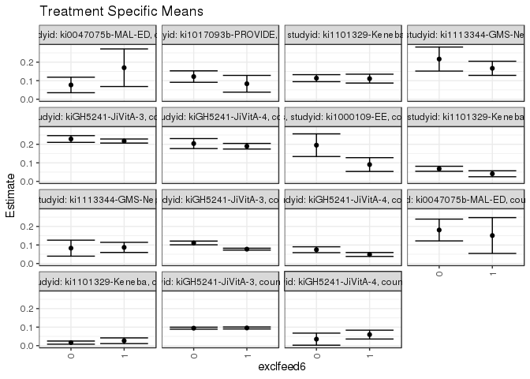

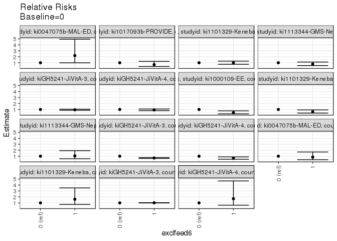

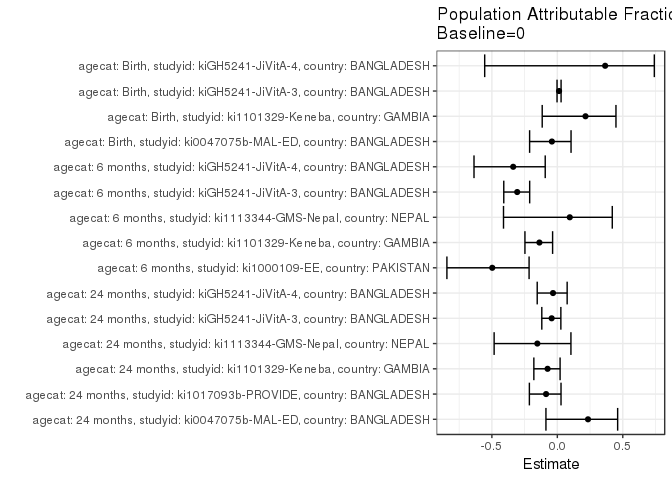

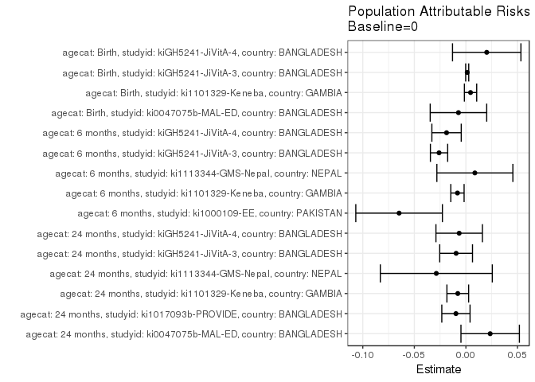

## Results Table

### Parameter: TSM

| agecat | studyid | country | intervention_level | baseline_level | estimate | ci_lower | ci_upper |
| --- | --- | --- | --- | --- | --- | --- | --- |
| Birth | ki0047075b-MAL-ED | BANGLADESH | 0 | NA | 0.1807229 | 0.1220537 | 0.2393920 |
| Birth | ki0047075b-MAL-ED | BANGLADESH | 1 | NA | 0.1509434 | 0.0543429 | 0.2475439 |
| Birth | ki1101329-Keneba | GAMBIA | 0 | NA | 0.0164473 | 0.0079484 | 0.0249461 |
| Birth | ki1101329-Keneba | GAMBIA | 1 | NA | 0.0265329 | 0.0111338 | 0.0419321 |
| Birth | kiGH5241-JiVitA-3 | BANGLADESH | 0 | NA | 0.0942508 | 0.0889058 | 0.0995959 |
| Birth | kiGH5241-JiVitA-3 | BANGLADESH | 1 | NA | 0.0954831 | 0.0902488 | 0.1007175 |
| Birth | kiGH5241-JiVitA-4 | BANGLADESH | 0 | NA | 0.0350877 | 0.0025210 | 0.0676545 |
| Birth | kiGH5241-JiVitA-4 | BANGLADESH | 1 | NA | 0.0597303 | 0.0358470 | 0.0836135 |
| 6 months | ki1000109-EE | PAKISTAN | 0 | NA | 0.1951060 | 0.1340160 | 0.2561959 |
| 6 months | ki1000109-EE | PAKISTAN | 1 | NA | 0.0906134 | 0.0534984 | 0.1277284 |
| 6 months | ki1101329-Keneba | GAMBIA | 0 | NA | 0.0679283 | 0.0543841 | 0.0814726 |
| 6 months | ki1101329-Keneba | GAMBIA | 1 | NA | 0.0410334 | 0.0250801 | 0.0569867 |
| 6 months | ki1113344-GMS-Nepal | NEPAL | 0 | NA | 0.0828652 | 0.0397013 | 0.1260292 |
| 6 months | ki1113344-GMS-Nepal | NEPAL | 1 | NA | 0.0869399 | 0.0596412 | 0.1142385 |
| 6 months | kiGH5241-JiVitA-3 | BANGLADESH | 0 | NA | 0.1110011 | 0.1010290 | 0.1209733 |
| 6 months | kiGH5241-JiVitA-3 | BANGLADESH | 1 | NA | 0.0773332 | 0.0722697 | 0.0823967 |
| 6 months | kiGH5241-JiVitA-4 | BANGLADESH | 0 | NA | 0.0743917 | 0.0586171 | 0.0901663 |
| 6 months | kiGH5241-JiVitA-4 | BANGLADESH | 1 | NA | 0.0488119 | 0.0382097 | 0.0594140 |
| 24 months | ki0047075b-MAL-ED | BANGLADESH | 0 | NA | 0.0769231 | 0.0350076 | 0.1188386 |
| 24 months | ki0047075b-MAL-ED | BANGLADESH | 1 | NA | 0.1698113 | 0.0684847 | 0.2711379 |
| 24 months | ki1017093b-PROVIDE | BANGLADESH | 0 | NA | 0.1221245 | 0.0912941 | 0.1529549 |
| 24 months | ki1017093b-PROVIDE | BANGLADESH | 1 | NA | 0.0833233 | 0.0381433 | 0.1285033 |
| 24 months | ki1101329-Keneba | GAMBIA | 0 | NA | 0.1135537 | 0.0946788 | 0.1324287 |
| 24 months | ki1101329-Keneba | GAMBIA | 1 | NA | 0.1110787 | 0.0871198 | 0.1350376 |
| 24 months | ki1113344-GMS-Nepal | NEPAL | 0 | NA | 0.2165846 | 0.1517703 | 0.2813989 |
| 24 months | ki1113344-GMS-Nepal | NEPAL | 1 | NA | 0.1666726 | 0.1285760 | 0.2047693 |
| 24 months | kiGH5241-JiVitA-3 | BANGLADESH | 0 | NA | 0.2285620 | 0.2104259 | 0.2466981 |
| 24 months | kiGH5241-JiVitA-3 | BANGLADESH | 1 | NA | 0.2174991 | 0.2065055 | 0.2284928 |
| 24 months | kiGH5241-JiVitA-4 | BANGLADESH | 0 | NA | 0.2039175 | 0.1769622 | 0.2308727 |
| 24 months | kiGH5241-JiVitA-4 | BANGLADESH | 1 | NA | 0.1895311 | 0.1743719 | 0.2046902 |

### Parameter: E(Y)

| agecat | studyid | country | intervention_level | baseline_level | estimate | ci_lower | ci_upper |
| --- | --- | --- | --- | --- | --- | --- | --- |
| Birth | ki0047075b-MAL-ED | BANGLADESH | NA | NA | 0.1735160 | 0.1232462 | 0.2237857 |
| Birth | ki1101329-Keneba | GAMBIA | NA | NA | 0.0209581 | 0.0132741 | 0.0286420 |
| Birth | kiGH5241-JiVitA-3 | BANGLADESH | NA | NA | 0.0955253 | 0.0903072 | 0.1007433 |
| Birth | kiGH5241-JiVitA-4 | BANGLADESH | NA | NA | 0.0552923 | 0.0348344 | 0.0757501 |
| 6 months | ki1000109-EE | PAKISTAN | NA | NA | 0.1303191 | 0.0962457 | 0.1643926 |
| 6 months | ki1101329-Keneba | GAMBIA | NA | NA | 0.0597484 | 0.0491105 | 0.0703864 |
| 6 months | ki1113344-GMS-Nepal | NEPAL | NA | NA | 0.0915751 | 0.0673602 | 0.1157900 |
| 6 months | kiGH5241-JiVitA-3 | BANGLADESH | NA | NA | 0.0849595 | 0.0801414 | 0.0897775 |
| 6 months | kiGH5241-JiVitA-4 | BANGLADESH | NA | NA | 0.0556338 | 0.0463917 | 0.0648759 |
| 24 months | ki0047075b-MAL-ED | BANGLADESH | NA | NA | 0.1004785 | 0.0596222 | 0.1413347 |
| 24 months | ki1017093b-PROVIDE | BANGLADESH | NA | NA | 0.1124567 | 0.0866788 | 0.1382347 |
| 24 months | ki1101329-Keneba | GAMBIA | NA | NA | 0.1056803 | 0.0901896 | 0.1211711 |
| 24 months | ki1113344-GMS-Nepal | NEPAL | NA | NA | 0.1878914 | 0.1528732 | 0.2229097 |
| 24 months | kiGH5241-JiVitA-3 | BANGLADESH | NA | NA | 0.2190767 | 0.2091475 | 0.2290059 |
| 24 months | kiGH5241-JiVitA-4 | BANGLADESH | NA | NA | 0.1974032 | 0.1830515 | 0.2117549 |

### Parameter: RR

| agecat | studyid | country | intervention_level | baseline_level | estimate | ci_lower | ci_upper |
| --- | --- | --- | --- | --- | --- | --- | --- |
| Birth | ki0047075b-MAL-ED | BANGLADESH | 0 | 0 | 1.0000000 | 1.0000000 | 1.0000000 |
| Birth | ki0047075b-MAL-ED | BANGLADESH | 1 | 0 | 0.8352201 | 0.4075190 | 1.7118038 |
| Birth | ki1101329-Keneba | GAMBIA | 0 | 0 | 1.0000000 | 1.0000000 | 1.0000000 |
| Birth | ki1101329-Keneba | GAMBIA | 1 | 0 | 1.6132140 | 0.7415472 | 3.5094995 |
| Birth | kiGH5241-JiVitA-3 | BANGLADESH | 0 | 0 | 1.0000000 | 1.0000000 | 1.0000000 |
| Birth | kiGH5241-JiVitA-3 | BANGLADESH | 1 | 0 | 1.0130749 | 0.9931690 | 1.0333798 |
| Birth | kiGH5241-JiVitA-4 | BANGLADESH | 0 | 0 | 1.0000000 | 1.0000000 | 1.0000000 |
| Birth | kiGH5241-JiVitA-4 | BANGLADESH | 1 | 0 | 1.7023121 | 0.6185571 | 4.6848816 |
| 6 months | ki1000109-EE | PAKISTAN | 0 | 0 | 1.0000000 | 1.0000000 | 1.0000000 |
| 6 months | ki1000109-EE | PAKISTAN | 1 | 0 | 0.4644317 | 0.2775911 | 0.7770307 |
| 6 months | ki1101329-Keneba | GAMBIA | 0 | 0 | 1.0000000 | 1.0000000 | 1.0000000 |
| 6 months | ki1101329-Keneba | GAMBIA | 1 | 0 | 0.6040690 | 0.3904232 | 0.9346251 |
| 6 months | ki1113344-GMS-Nepal | NEPAL | 0 | 0 | 1.0000000 | 1.0000000 | 1.0000000 |
| 6 months | ki1113344-GMS-Nepal | NEPAL | 1 | 0 | 1.0491719 | 0.5724630 | 1.9228522 |
| 6 months | kiGH5241-JiVitA-3 | BANGLADESH | 0 | 0 | 1.0000000 | 1.0000000 | 1.0000000 |
| 6 months | kiGH5241-JiVitA-3 | BANGLADESH | 1 | 0 | 0.6966885 | 0.6261890 | 0.7751252 |
| 6 months | kiGH5241-JiVitA-4 | BANGLADESH | 0 | 0 | 1.0000000 | 1.0000000 | 1.0000000 |
| 6 months | kiGH5241-JiVitA-4 | BANGLADESH | 1 | 0 | 0.6561469 | 0.4854464 | 0.8868718 |
| 24 months | ki0047075b-MAL-ED | BANGLADESH | 0 | 0 | 1.0000000 | 1.0000000 | 1.0000000 |
| 24 months | ki0047075b-MAL-ED | BANGLADESH | 1 | 0 | 2.2075472 | 0.9839470 | 4.9527714 |
| 24 months | ki1017093b-PROVIDE | BANGLADESH | 0 | 0 | 1.0000000 | 1.0000000 | 1.0000000 |
| 24 months | ki1017093b-PROVIDE | BANGLADESH | 1 | 0 | 0.6822817 | 0.3751559 | 1.2408397 |
| 24 months | ki1101329-Keneba | GAMBIA | 0 | 0 | 1.0000000 | 1.0000000 | 1.0000000 |
| 24 months | ki1101329-Keneba | GAMBIA | 1 | 0 | 0.9782038 | 0.7476148 | 1.2799139 |
| 24 months | ki1113344-GMS-Nepal | NEPAL | 0 | 0 | 1.0000000 | 1.0000000 | 1.0000000 |
| 24 months | ki1113344-GMS-Nepal | NEPAL | 1 | 0 | 0.7695499 | 0.5284683 | 1.1206102 |
| 24 months | kiGH5241-JiVitA-3 | BANGLADESH | 0 | 0 | 1.0000000 | 1.0000000 | 1.0000000 |
| 24 months | kiGH5241-JiVitA-3 | BANGLADESH | 1 | 0 | 0.9515980 | 0.8679565 | 1.0432996 |
| 24 months | kiGH5241-JiVitA-4 | BANGLADESH | 0 | 0 | 1.0000000 | 1.0000000 | 1.0000000 |
| 24 months | kiGH5241-JiVitA-4 | BANGLADESH | 1 | 0 | 0.9294498 | 0.8005854 | 1.0790565 |

### Parameter: PAR

| agecat | studyid | country | intervention_level | baseline_level | estimate | ci_lower | ci_upper |
| --- | --- | --- | --- | --- | --- | --- | --- |
| Birth | ki0047075b-MAL-ED | BANGLADESH | 0 | NA | -0.0072069 | -0.0346114 | 0.0201975 |
| Birth | ki1101329-Keneba | GAMBIA | 0 | NA | 0.0045108 | -0.0014504 | 0.0104720 |
| Birth | kiGH5241-JiVitA-3 | BANGLADESH | 0 | NA | 0.0012745 | -0.0001996 | 0.0027485 |
| Birth | kiGH5241-JiVitA-4 | BANGLADESH | 0 | NA | 0.0202045 | -0.0129696 | 0.0533786 |
| 6 months | ki1000109-EE | PAKISTAN | 0 | NA | -0.0647868 | -0.1067871 | -0.0227866 |
| 6 months | ki1101329-Keneba | GAMBIA | 0 | NA | -0.0081799 | -0.0146267 | -0.0017331 |
| 6 months | ki1113344-GMS-Nepal | NEPAL | 0 | NA | 0.0087098 | -0.0281465 | 0.0455662 |
| 6 months | kiGH5241-JiVitA-3 | BANGLADESH | 0 | NA | -0.0260417 | -0.0344212 | -0.0176622 |
| 6 months | kiGH5241-JiVitA-4 | BANGLADESH | 0 | NA | -0.0187579 | -0.0330039 | -0.0045118 |
| 24 months | ki0047075b-MAL-ED | BANGLADESH | 0 | NA | 0.0235554 | -0.0047887 | 0.0518995 |
| 24 months | ki1017093b-PROVIDE | BANGLADESH | 0 | NA | -0.0096677 | -0.0233627 | 0.0040273 |
| 24 months | ki1101329-Keneba | GAMBIA | 0 | NA | -0.0078734 | -0.0184079 | 0.0026610 |
| 24 months | ki1113344-GMS-Nepal | NEPAL | 0 | NA | -0.0286932 | -0.0830088 | 0.0256225 |
| 24 months | kiGH5241-JiVitA-3 | BANGLADESH | 0 | NA | -0.0094853 | -0.0253832 | 0.0064126 |
| 24 months | kiGH5241-JiVitA-4 | BANGLADESH | 0 | NA | -0.0065143 | -0.0290495 | 0.0160210 |

### Parameter: PAF

| agecat | studyid | country | intervention_level | baseline_level | estimate | ci_lower | ci_upper |
| --- | --- | --- | --- | --- | --- | --- | --- |
| Birth | ki0047075b-MAL-ED | BANGLADESH | 0 | NA | -0.0415346 | -0.2117738 | 0.1047882 |
| Birth | ki1101329-Keneba | GAMBIA | 0 | NA | 0.2152308 | -0.1155375 | 0.4479230 |
| Birth | kiGH5241-JiVitA-3 | BANGLADESH | 0 | NA | 0.0133417 | -0.0021878 | 0.0286305 |
| Birth | kiGH5241-JiVitA-4 | BANGLADESH | 0 | NA | 0.3654135 | -0.5549497 | 0.7410206 |
| 6 months | ki1000109-EE | PAKISTAN | 0 | NA | -0.4971398 | -0.8436343 | -0.2157658 |
| 6 months | ki1101329-Keneba | GAMBIA | 0 | NA | -0.1369057 | -0.2474809 | -0.0361318 |
| 6 months | ki1113344-GMS-Nepal | NEPAL | 0 | NA | 0.0951115 | -0.4111822 | 0.4197609 |
| 6 months | kiGH5241-JiVitA-3 | BANGLADESH | 0 | NA | -0.3065188 | -0.4092216 | -0.2113009 |
| 6 months | kiGH5241-JiVitA-4 | BANGLADESH | 0 | NA | -0.3371670 | -0.6366164 | -0.0925074 |
| 24 months | ki0047075b-MAL-ED | BANGLADESH | 0 | NA | 0.2344322 | -0.0870450 | 0.4608374 |
| 24 months | ki1017093b-PROVIDE | BANGLADESH | 0 | NA | -0.0859684 | -0.2135434 | 0.0281952 |
| 24 months | ki1101329-Keneba | GAMBIA | 0 | NA | -0.0745023 | -0.1794145 | 0.0210777 |
| 24 months | ki1113344-GMS-Nepal | NEPAL | 0 | NA | -0.1527113 | -0.4828330 | 0.1039156 |
| 24 months | kiGH5241-JiVitA-3 | BANGLADESH | 0 | NA | -0.0432967 | -0.1186253 | 0.0269593 |
| 24 months | kiGH5241-JiVitA-4 | BANGLADESH | 0 | NA | -0.0329997 | -0.1536803 | 0.0750570 |